# Introduction to my homework

Guo Bangwei

2020-12-17

## The homework 0 2020-09-22

### Question

Use knitr to produce 3 examples in the book. The 1st example should contain texts and at least one figure. The 2nd example should contains texts and at least one table. The 3rd example should contain at least a couple of LaTeX formulas.

### Answer

#### Example 1

This is a Q-Qplot picture.

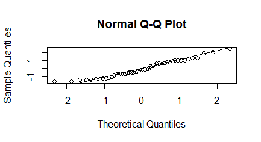

#### Example 2

This is a table

```
##
##     a b c
##   a 0 0 1
##   b 1 0 0
##   c 0 1 0
```

#### Example 3

They are LATEX equations.

$$H_{n}\left(\beta_{n}\right)=\sum_{i=1}^{n} X_{i} \dot{\pi}_{i}\left(\beta_{n}\right) A_{i}^{-1 / 2}\left(\beta_{n}\right) \hat{R}_{n}^{-1} A_{i}^{-1 / 2}\left(\beta_{n}\right) \dot{\pi}_{i}^{\tau}\left(\beta_{n}\right) X_{i}^{\tau}$$
$$\hat{M}_{n}\left(\beta_{n}\right)=\sum_{i=1}^{n} X_{i} \dot{\pi}_{i}\left(\beta_{n}\right) A_{i}^{-1 / 2}\left(\beta_{n}\right) \hat{R}_{n}^{-1} \bar{\epsilon}_{i}\left(\beta_{n}\right) \bar{\epsilon}_{i}^{\tau}\left(\beta_{n}\right) \hat{R}_{n}^{-1} A_{i}^{-1 / 2}\left(\beta_{n}\right) \dot{\pi}_{i}^{\tau}\left(\beta_{n}\right) X_{i}^{\tau}$$

## The homework 1 2020-10-05

### Question

Exercises 3.3, 3.9, 3.10, and 3.13 (pages 94-95, Statistical Computating with R).

### Answer

#### 3.3

$F^{-1}(U)=\frac{2}{\sqrt{1-u}}$,求导可得密度函数为$f(x)=\frac{8}{x^{3}},x\geq 2$

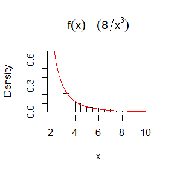

```r
set.seed(1998)
n <- 1000
u <- runif(n)
x <- 2/sqrt(1-u)
hist(x, breaks=500,xlim=c(2,10),prob = TRUE, main = expression(f(x)==(8/x^3)))
y <- seq(2, 10, .01)
lines(y, 8*y^(-3),col="red")
```

#### 3.9:

取50000个随机数

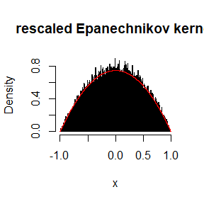

```r
set.seed(1998)
n<-50000
u1 <- runif(n,-1,1)
u2 <- runif(n,-1,1)
u3 <- runif(n,-1,1)
u4 <-rep(0,n)
for (i in 1:n) {
  if(abs(u3[i])>=abs(u1[i])&&abs(u3[i])>=abs(u2[i]))
    u4[i]<-u2[i]
  else u4[i]<-u3[i]
}
hist(u4, breaks=500,xlim=c(-1,1),xlab="x",prob = TRUE,main="rescaled Epanechnikov kernel")
y <- seq(-1, 1, .0002)
lines(y,0.75*(1-y^2),col="red")
```

#### 3.10

令通过该算法得到的结果变量为$U_4$,
$$P(U_4=u)
=P(U_2=u,|U_3|\geq|U_2|,|U_3|\geq|U_1|)+P(U_3=u,|U_3|<|U_2|,|U_3|<|U_1|)\\
+P(U_3=u,|U_3|<|U_2|,|U_3|\geq|U_1|)+P(U_2=u,|U_3|\geq|U_2|,|U_3|<|U_1|)\\
=\frac{1}{2}(1-|u|)\frac{1+|u|}{2}+\frac{1}{2}(1-|u|)^2+(1-|u|)|u|\\
=\frac{3}{4}(1-u^2)$$

从而验证了算法

#### 3.13

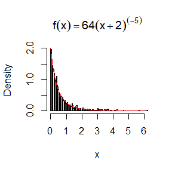

```r
set.seed(1998)
n <- 1000
u <- runif(n)
x <- 2/(1-u)^(0.25)-2 #反解
hist(x, breaks=500,xlim=c(0,6),prob = TRUE, main = expression(f(x)==64(x+2)^(-5)))
y <- seq(0, 6, .01)
lines(y,64*(y+2)^(-5),col="red" )
```

## The homework 2 2020-10-13

### Question

Exercises 5.1, 5.7, and 5.11 (pages 149-151, Statistical Computating with R).

### Answer

#### 5.1

使用蒙特卡洛方法估计积分 $\int_0^\frac{\pi}{3}sin(t)dt$,取$f(x)$为 $U[0,\frac{\pi}{3}]$

```r
set.seed(1998)
k<-10000
X<-runif(k,0,pi/3)
Y<-mean(pi/3*sin(X))
Y#蒙特卡洛积分估计值#
```

```
## [1] 0.5001146
```

下面计算真实值

```r
truevalue<--cos(pi/3)+cos(0)
truevalue
```

```
## [1] 0.5
```

#### 5.7

根据5.6的计算，当$U\sim U[0,1]$，$var(e^U+e^{1-U})=10e-3e^2-5,var(e^U)=2e-\frac{1}{2}e^2-\frac{3}{2}$  
传统的MC方法的方差为$var(\theta_1)=\frac{1}{m}var(e^U)$，改进后的方法的方差为$var(\theta_2)=\frac{1}{\frac{n}{2}}var(\frac{e^U+e^{1-U}}{2})=\frac{1}{2n}var(e^U+e^{1-U})$  
代入可得理论的改进效率为$96.8$%

```r
set.seed(1998)
m<-100000
X<-runif(m,0,1)
Y<-mean(exp(X))
theta<-exp(X)
FANGCHA<-1/m*var(theta)
FANGCHA#使用传统MC方法的方差#
```

```
## [1] 2.420469e-06
```

```r
FANGCHA2<-1/(2*m)*var(exp(X[1:(k/2)])+exp((1-X)[1:(k/2)]))
FANGCHA2#使用Inverse transformation method后的方差#
```

```
## [1] 8.04137e-08
```

```r
(FANGCHA-FANGCHA2)/FANGCHA#降低方差的效率#
```

```
## [1] 0.9667776
```

```r
a1<-10*exp(1)-3*exp(1)^2-5
a2<-2*exp(1)-0.5*exp(1)^2-1.5
(a2-a1/2)/a2#理论效率#
```

```
## [1] 0.9676701
```

#### 5.11

将$Var(\hat{\theta}_c)=E(\hat{\theta_1}-\hat{\theta_2})^2c^2+2Cov(\hat{\theta_2},\hat{\theta_1}-\hat{\theta_2})c+var(\hat{\theta_2})$看作关于c的二次函数  
对称轴：$\frac{Var(\hat{\theta_2})-Cov(\hat{\theta_1},\hat{\theta_2})}{var(\hat{\theta_1}-\hat{\theta_2})}$  
当对称轴大于0，c取对称轴值时，方差最小  
当对称轴小于0，c=0时，方差最小

## The homework 3 2020-10-20

### Question

Exercises 5.13, 5.15, 6.4, and 6.5 (page 151 and 180, Statistical Computating with R).

### Answer

#### 5.13

先画出$g(x)$的图像

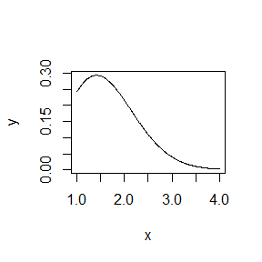

```r
x<- seq(1.01,4,.01)
y<-((x^2)*exp(-0.5*x^2))/((2*pi)^0.5)
g<-function(x){
   ((x^2)*exp(-0.5*x^2))/((2*pi)^0.5)*(x>1)
}
plot(x,y,type = "l")
```

取important function $f_1$为$N(1.5,1),x>1$。

```r
set.seed(1998)
m<-10000
X1<-rnorm(m,1.5,1)
Y1<-mean(g(X1)/dnorm(X1,1.5,1))
var1<-var(g(X1)/dnorm(X1,1.5,1))
Y1
```

```
## [1] 0.3999798
```

```r
var1#这里var1是g(X)/f1(X)的方差
```

```
## [1] 0.0912881
```

取important function $f_2$为$e^{-x},x>1$。

```r
set.seed(1998)
m<-10000
X2<-rexp(m,1)
Y2<-mean(g(X2)/dexp(X2,1))
var2<-var(g(X2)/dexp(X2,1))
Y2
```

```
## [1] 0.4088727
```

```r
var2#这里var2是g(X)/f2(X)的方差
```

```
## [1] 0.3476336
```

从而可以看出，取N(1.5,1)时的方差更好，因为此时$f_1(x)$与$g(x)$的图像更接近。

#### 5.15

```r
set.seed(1998)
m<-2000
g<-function(x){
  exp(-x)/(1+x^2)*(x>0)*(x<1)
}
f<-function(x){
  exp(-x)/(1-exp(-1))
}
a<-rep(0,6)
a[1]<-0
for(i in 1:5){
a[i+1]<-qexp((1-exp(-1))*i/5,1)}#生成区间段点
result<-matrix(rep(0,10),ncol=2)
for (i in 1:5) {
  rn<- runif(m,0,1)
  q<- -log(1-((1-exp(-1))*(rn + i -1)/5))
  re<- g(q)/((5*(exp(-q)))/(1-exp(-1)))
  result[i,1]<- mean(re)
  result[i,2]<- var(re)
}
cat("theta的估计是:",sum(result[,1]))
```

```
## theta的估计是: 0.5247964
```

```r
cat("标准差是:",sqrt(sum(result[,2])))
```

```
## 标准差是: 0.009316495
```

显然相比较与Example 5.10中的方法更为优越

#### 6.4

先从参数为0；1的对数正态分布中抽样，再计算$\mu$ 理论上95%的置信区间,再计算这些区间包含 0的频率。

```r
set.seed(1998)
n<- 20
alpha<- 0.05
t<-0
s<- matrix(rep(0,20000),nrow =10000)
for (i in 1:10000) {
  x<- rlnorm(n,0,1)
  s[i,1]<- mean(log(x))+sd(log(x))*qt(alpha/2,n-1)/(n-1)^0.5
  s[i,2]<- mean(log(x))-sd(log(x))*qt(alpha/2,n-1)/(n-1)^0.5
  if(s[i,2]>0 & s[i,1]< 0)
    t<-t+1
}
t/10000
```

```
## [1] 0.9581
```

即构造的置信区间的置信系数比较接近理论值。

#### 6.5

```r
set.seed(1998)
n<- 20
alpha<- 0.05
t<-0
re<- matrix(rep(0,20000),nrow =10000)
for (i in 1:10000) {
  x<- rchisq(n,2)
  re[i,1]<- mean(x)+sd(x)*qt(alpha/2,n-1)/sqrt(n-1)
  re[i,2]<- mean(x)-sd(x)*qt(alpha/2,n-1)/sqrt(n-1)
  if(re[i,2]>2 & re[i,1]< 2){
    t<-t+1}
}
t/10000
```

```
## [1] 0.924
```

相比样本来自正态分布的置信系数较低，但是更稳健。

## The homework 4 2020-10-27

### Question

Exercises 6.7, 6.8, and 6.C (pages 180-182, Statistical Computating with R).

Discussion:  
If we obtain the powers for two methods under a particular simulation setting with 10,000 experiments: say, 0.651 for one method and 0.676 for another method. Can we say the powers are different at 0.05 level?  
What is the corresponding hypothesis test problem?  
What test should we use? Z-test, two-sample t-test, paired-t test or McNemar test?  
What information is needed to test your hypothesis?

### Answer

#### 6.7

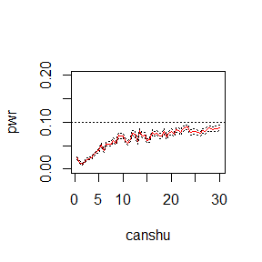

```r
set.seed(1998)
sk <- function(x) {
#computes the sample skewness coeff.
xbar <- mean(x)
m3 <- mean((x - xbar)^3)
m2 <- mean((x - xbar)^2)
return( m3 / m2^1.5 )
}
alpha <- .1
n <- 30
m <- 2500
canshu <- c(seq(0.5,30,0.5))
N <- length(canshu)
pwr <- numeric(N)
#critical value for the skewness test
cv <- qnorm(1-alpha/2, 0, sqrt(6*(n-2) / ((n+1)*(n+3))))
for (j in 1:N) {
  e <- canshu[j]
  sktests <- numeric(m)
  for (i in 1:m) { #for each replicate
    x <- rbeta(n,e,e)
    sktests[i] <- as.integer(abs(sk(x)) >= cv)
  }
  pwr[j] <- mean(sktests)
}
#plot power vs epsilon
plot(canshu, pwr, type = "l",
     xlab = bquote(canshu), ylim = c(0,0.2),col='red')
abline(h = .1, lty = 3)
se <- sqrt(pwr * (1-pwr) / m) #add standard errors
lines(canshu, pwr+se, lty = 3)
lines(canshu, pwr-se, lty = 3)
```

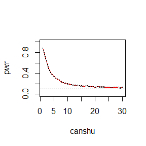

```r
set.seed(1998)
sk <- function(x) {
#computes the sample skewness coeff.
xbar <- mean(x)
m3 <- mean((x - xbar)^3)
m2 <- mean((x - xbar)^2)
return( m3 / m2^1.5 )
}
alpha <- .1
n <- 30
m <- 2500
canshu <- c(seq(1,30,1))
N <- length(canshu)
pwr <- numeric(N)
#critical value for the skewness test
cv <- qnorm(1-alpha/2, 0, sqrt(6*(n-2) / ((n+1)*(n+3))))
for (j in 1:N) {
  e <- canshu[j]
  sktests <- numeric(m)
  for (i in 1:m) { #for each replicate
    x <- rt(n,e)
    sktests[i] <- as.integer(abs(sk(x)) >= cv)
  }
  pwr[j] <- mean(sktests)
}
#plot power vs epsilon
plot(canshu, pwr, type = "l",
     xlab = bquote(canshu), ylim = c(0,1),col='red')
abline(h = .1, lty = 3)
se <- sqrt(pwr * (1-pwr) / m) #add standard errors
lines(canshu, pwr+se, lty = 3)
lines(canshu, pwr-se, lty = 3)
```

从功效图像可以看出，随着$t(\gamma)$中$\gamma$的增大，t分布越来越趋向于正态分布,功效会接近置信系数。

#### 6.8:

先生成一个Count5检验和F检验的函数

```r
count5test <- function(x, y) {
X <- x - mean(x)
Y <- y - mean(y)
outx <- sum(X > max(Y)) + sum(X < min(Y))
outy <- sum(Y > max(X)) + sum(Y < min(X))
# return 1 (reject) or 0 (do not reject H0)
return(as.integer(max(c(outx, outy)) > 5))
}
Ftest<- function(x,y){
  xl<- length(x)
  yl<- length(y)
  sx<- var(x)
  sy<- var(y)
  T<- sy/sx
  return(as.integer(T<qf(0.055/2,xl-1,yl-2)|T>qf(1-0.055/2,xl-1,yl-1)))
}
```

再写一个样本量为自变量的生成两种检验功效的函数：

```r
set.seed(1998)
compare<-function(n){
m <- 1000
sigma1 <- 1
sigma2 <- 1.5
power1 <- mean(replicate(m, expr={
x <- rnorm(n, 0, sigma1)
y <- rnorm(n, 0, sigma2)
count5test(x, y)
}))
power2 <- mean(replicate(m, expr={
x <- rnorm(n, 0, sigma1)
y <- rnorm(n, 0, sigma2)
Ftest(x, y)
}))
cat("这是样本量为n的时候count5检验的功效",power1)
cat("\n这是样本量为n的时候F检验的功效",power2)}
compare(10)#小样本情况
```

```
## 这是样本量为n的时候count5检验的功效 0.093
## 这是样本量为n的时候F检验的功效 0.212
```

```r
compare(50)#中样本情况
```

```
## 这是样本量为n的时候count5检验的功效 0.659
## 这是样本量为n的时候F检验的功效 0.801
```

```r
compare(500)#大样本情况
```

```
## 这是样本量为n的时候count5检验的功效 0.989
## 这是样本量为n的时候F检验的功效 1
```

可以看出，随着样本量的增大，功效越来越接近于1。其中F检验的功效会更大。

#### 6.C

Discussion: 1.原假设：两种检验功效相等 2.大样本利用中心极限定理进行正态化近似，然后进行两正态分布的均值检验 3.因为MC检验法实际上已经在此功效下的二项分布抽样，所以题目已知数据已经足够。

## The homework 5 2020-11-04

### Question

Exercises 7.1, 7.5, 7.8, and 7.11 (pages 212-213, Statistical Computating with R).

### Answer

####7.1:

Compute a jackknife estimate of the bias

```r
library(bootstrap)
law<-law82
n <- nrow(law)
LSAT<- law$LSAT
GPA<- law$GPA
cor<-cor(LSAT,GPA)
print (cor)
```

```
## [1] 0.7599979
```

```r
#compute the jackknife replicates
cor.jack <- numeric(n)
for (i in 1:n)
cor.jack[i] <- cor(LSAT[-i],GPA[-i])
bias <- (n - 1) * (mean(cor.jack) -cor)
print(bias) #jackknife estimate of bias
```

```
## [1] -0.002938591
```

Compute a jackknife estimate of the standard error

```r
se <- sqrt((n-1) *mean((cor.jack - mean(cor.jack))^2))
print(se)#jackknife estimate of standard error
```

```
## [1] 0.05334785
```

#### 7.5

Use the boot function in the package “boot” to compute the 95% bootstrap confidence intervals for the mean time between failures

```r
library(boot)
library(bootstrap)
set.seed(1237)
air<-aircondit
meMLE<-function(x,i){
  xi<-x[i,1]
  lamda<-length(xi)/sum(xi)
  return(1/lamda)
}
obj <- boot(data =air, statistic=meMLE, R = 2000)
print(boot.ci(obj,type = c("basic", "norm", "perc","bca")))
```

```
## BOOTSTRAP CONFIDENCE INTERVAL CALCULATIONS
## Based on 2000 bootstrap replicates
##
## CALL :
## boot.ci(boot.out = obj, type = c("basic", "norm", "perc", "bca"))
##
## Intervals :
## Level      Normal              Basic
## 95%   ( 37.4, 181.8 )   ( 25.6, 167.9 )
##
## Level     Percentile            BCa
## 95%   ( 48.2, 190.6 )   ( 60.1, 244.4 )
## Calculations and Intervals on Original Scale
## Some BCa intervals may be unstable
```

Because the various approximate distributions used to generate all kinds of confidence intervals are different, the confidence intervals are different.

#### 7.8

Refer to Exercise 7.7. Obtain the jackknife estimates of bias and standard error of $\hat{\theta}$

```r
library(boot)
thett<-function(x){
eg<-eigen(cov(x))$values
theta<-eg[1]/sum(eg)
return(theta)}
theta<-thett(scor)
n<-nrow(scor)
theta.jack <- numeric(n)
for (i in 1:n){
theta.jack[i] <-thett(scor[-i,])
}
bias <- (n - 1)* (mean(theta.jack) -theta)
bias
```

```
## [1] 0.001069139
```

Compute a jackknife estimate of the standard error

```r
se <- sqrt((n-1) *mean((theta.jack - mean(theta))^2))
print(se)#jackknife estimate of standard error
```

```
## [1] 0.04955244
```

#### 7.11

Use leave-two-out cross validation to compare the models

```r
library(DAAG); attach(ironslag)
```

```r
a <- seq(10, 40, .1) #sequence for plotting fits
L1 <- lm(magnetic ~ chemical)
yhat1 <- L1$coef[1] + L1$coef[2] * a
L2 <- lm(magnetic ~ chemical + I(chemical^2))
yhat2 <- L2$coef[1] + L2$coef[2] * a + L2$coef[3] * a^2
L3 <- lm(log(magnetic) ~ chemical)
logyhat3 <- L3$coef[1] + L3$coef[2] * a
yhat3 <- exp(logyhat3)
L4 <- lm(log(magnetic) ~ log(chemical))
logyhat4 <- L4$coef[1] + L4$coef[2] * log(a)

n <- length(magnetic) #in DAAG ironslag
e1 <- e2 <- e3 <- e4 <- matrix(rep(0,n^2),nrow=n)
# for n-fold cross validation
# fit models on leave-one-out samples
for (k in 1:(n-1)) {
  for (m in (k+1):n) {
    y <- magnetic[-k][-(m-1)]
    x <- chemical[-k][-(m-1)]
J1 <- lm(y ~ x)
yhat11 <- J1$coef[1] + J1$coef[2] * chemical[k]
yhat12 <- J1$coef[1] + J1$coef[2] * chemical[m]
e1[k,k] <- magnetic[k] - yhat11
e1[k,m] <- magnetic[m] - yhat12
J2 <- lm(y ~ x + I(x^2))
yhat21 <- J2$coef[1] + J2$coef[2] * chemical[k] +J2$coef[3] * chemical[k]^2
yhat22 <- J2$coef[1] + J2$coef[2] * chemical[m] +J2$coef[3] * chemical[m]^2
e2[k,k] <- magnetic[k] - yhat21
e2[k,m] <- magnetic[m] - yhat22
J3 <- lm(log(y) ~ x)
logyhat31 <- J3$coef[1] + J3$coef[2] * chemical[k]
logyhat32 <- J3$coef[1] + J3$coef[2] * chemical[m]
yhat31 <- exp(logyhat31)
yhat32 <- exp(logyhat32)
e3[k,k] <- magnetic[k] - yhat31
e3[k,m] <- magnetic[m] - yhat32
J4 <- lm(log(y) ~ log(x))
logyhat41 <- J4$coef[1] + J4$coef[2] * log(chemical[k])
logyhat42 <- J4$coef[1] + J4$coef[2] * log(chemical[m])
yhat41 <- exp(logyhat41)
yhat42 <- exp(logyhat42)
e4[k,k] <- magnetic[k] - yhat41
e4[k,m] <- magnetic[k] - yhat41
}
}
ee1<-e1[e1!=0]
ee2<-e2[e2!=0]
ee3<-e3[e3!=0]
ee4<-e4[e4!=0]
print(c(mean(ee1^2),mean(ee2^2),mean(ee3^2),mean(ee4^2)))
```

```
## [1] 24.82267 22.45861 24.54945 12.92996
```

It can be seen that the fourth model is better because $\sigma^2_{\epsilon}$ is smaller

## The homework 6 2020—11-11

### Question

1.Exercise 8.3 (page 243, Statistical Computating with R).

2.Design experiments for evaluating the performance of the NN,energy, and ball methods in various situations.

(1)Unequal variances and equal expectations

(2)Unequal variances and unequal expectations

(3)Non-normal distributions: t distribution with 1 df (heavy-tailed distribution), bimodel distribution (mixture of two normal distributions)

(4)Unbalanced samples (say, 1 case versus 10 controls)

Note: The parameters should be chosen such that the powers are distinguishable (say, range from 0.3 to 0.8).

### Answer

#### 1.

According to the reference [193] R. N. McGrath and B. Y. Yeh. Count Five test for equal variance. The American Statistician, 59:47–53, 2005. We adopt the method in the paper to solve the case that sample sizes are unequal.
$$P\left(C_{x}^{(\mu)} \geq m \mid H_{0}\right) \approx\left(\frac{n_{x}}{n_{x}+n_{y}}\right)^{m}$$
Treating it as an equality and letting $P\left(C_{x}^{(\mu)} \geq m \mid H_{0}\right)=\alpha / 2$, I may solve for $\alpha / 2$ for a given $m$, or vice versa as we show in the following example. Take $n_1=200, n_2=300,\alpha=0.065$, becasue $n_1,n_2>>m$. So I solve that $m_{n_2}=7$. In the base of the function Count5test, write the function Countmtest. Then generate samples by permutation method to calculate the mean

```r
set.seed(2443)
countmtest <- function(x,y,m) {
X <- x - mean(x)
Y <- y - mean(y)
outx <- sum(X > max(Y)) + sum(X < min(Y))
outy <- sum(Y > max(X)) + sum(Y < min(X))
# return 1 (reject) or 0 (do not reject H0)
return(as.integer(max(c(outx, outy)) > m))
}
n1 <- 200
n2 <- 300
mu1 <- mu2 <- 0
sigma1 <- sigma2 <- 1
m <- 10000
x <- rnorm(n1, mu1, sigma1)
y <- rnorm(n2, mu2, sigma2)
R <- 999 #number of replicates
z <- c(x, y) #pooled sample
K <- 1:(length(z))
reps <- numeric(R) #storage for replicates
for (i in 1:R) {
#generate indices k for the first sample
k <- sample(K, size =length(x), replace = FALSE)
x1 <- z[k]
y1 <- z[-k] #complement of x1
reps[i] <- countmtest(x1, y1,7)
}
mean(reps)
```

```
## [1] 0.05305305
```

We can see that the Type I error ≤ 0.0625 when we use this method.

## The homework 7 2020—11—18

### Question

(1)Exercies 9.4 (pages 277, Statistical Computating with R).

(2)For Exercise 9.4, use the Gelman-Rubin method to monitor convergence of the chain, and run the chain until it converges approximately to the target distribution according to $\hat{R}<1.2$.

(3)Exercises 11.4 (pages 353, Statistical Computing with R)

### Answer

#### (1).

Use $N(X_t|\sigma^2)$ to generate the chain. According to the example 9.3 of the book, I aim to observe the change of the chain,so I set $X_0=20$

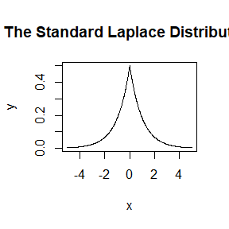

```r
fl<-function(x) 0.5*exp(-abs(x))
x<-seq(-5,5,0.01)
y<-fl(x)
plot(x,y,type='l',main='The Standard Laplace Distribution')
```

```r
rw.Metropolis <- function(sigma, x0, N) {
  x <- numeric(N)
  x[1] <- x0
  u <- runif(N)
  k <- 0
  for (i in 2:N) {
    y <- rnorm(1, x[i-1], sigma)
    if (u[i] <= (fl(y) / fl(x[i-1])))
      x[i] <- y else {
        x[i] <- x[i-1]
        k <- k + 1
      }
  }
  return(list(x=x, k=k))
}
N <- 2000
sigma <- c(.05, .5, 2, 16)
x0 <- 20
set.seed(1278)
rw1 <- rw.Metropolis(sigma[1], x0, N)
rw2 <- rw.Metropolis(sigma[2], x0, N)
rw3 <- rw.Metropolis(sigma[3], x0, N)
rw4 <- rw.Metropolis(sigma[4], x0, N)
#number of candidate points rejected
print(c(1-rw1$k/2000, 1-rw2$k/2000, 1-rw3$k/2000, 1-rw4$k/2000))#the acceptance rates
```

```
## [1] 0.9770 0.8310 0.5430 0.0855
```

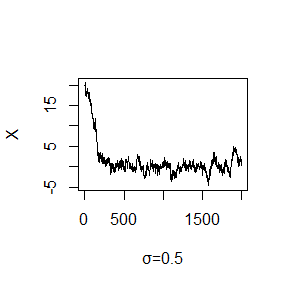

```r
par(mfrow=c(1,1))
plot(1:length(rw2$x),rw2$x,type = 'l',xlab = 'σ=0.5',ylab = 'X')
```

#### (2).

For Exercise 9.4, use the Gelman-Rubin method to monitor convergence of the chain, and run the chain until it converges approximately to the target distribution according to $\hat{R}<1.2$.

```r
Gelman.Rubin <- function(psi) {
# psi[i,j] is the statistic psi(X[i,1:j])
# for chain in i-th row of X
psi <- as.matrix(psi)
n <- ncol(psi)
k <- nrow(psi)
psi.means <- rowMeans(psi) #row means
B <- n * var(psi.means) #between variance est.
psi.w <- apply(psi, 1, "var") #within variances
W <- mean(psi.w) #within est.
v.hat <- W*(n-1)/n + (B/n) #upper variance est.
r.hat <- v.hat / W #G-R statistic
return(r.hat)
}
```

#### (3).

Exercises 11.4 (pages 353, Statistical Computing with R)

Use the uniroot function to generate root and write a big function to solve all k.

```r
soroot<-function(K){
N<-length(K)
root<-1:N
for (i in 1:length(K)) {
  k<-K[i]
  S1<-function(a){
   re1<-1-pt(sqrt(a^2*(k-1)/(k-a^2)),df=(k-1))
   re2<-1-pt(sqrt(a^2*k/((k+1)-a^2)),df=k)
   return(re1-re2)
   }
  root[i]<-uniroot(S1,c(0.001,2))$root
}
print(root)
}
soroot(4:25)#k=4:25
```

```
##  [1] 1.492103 1.533556 1.562745 1.584430 1.601185 1.614521 1.625390 1.634419
##  [9] 1.642038 1.648554 1.654191 1.659114 1.663452 1.667304 1.670746 1.673840
## [17] 1.676637 1.679178 1.681496 1.683620 1.685572 1.687374
```

```r
soroot(4:100)#k=4:100
```

```
##  [1] 1.492103 1.533556 1.562745 1.584430 1.601185 1.614521 1.625390 1.634419
##  [9] 1.642038 1.648554 1.654191 1.659114 1.663452 1.667304 1.670746 1.673840
## [17] 1.676637 1.679178 1.681496 1.683620 1.685572 1.687374 1.689040 1.690588
## [25] 1.692027 1.693370 1.694626 1.695803 1.696909 1.697949 1.698929 1.699854
## [33] 1.700705 1.701534 1.702320 1.703067 1.703777 1.704453 1.705098 1.705713
## [41] 1.706301 1.706863 1.707401 1.707916 1.708411 1.708886 1.709341 1.709780
## [49] 1.710202 1.710608 1.710999 1.711376 1.711740 1.712092 1.712431 1.712759
## [57] 1.713076 1.713383 1.713681 1.713969 1.714248 1.714518 1.714781 1.715036
## [65] 1.715283 1.715523 1.715757 1.715984 1.716204 1.716419 1.716628 1.716832
## [73] 1.717030 1.717223 1.717411 1.717595 1.717774 1.717948 1.718119 1.718285
## [81] 1.718447 1.718606 1.718761 1.718912 1.719060 1.719205 1.719347 1.719485
## [89] 1.719621 1.719753 1.719883 1.720010 1.720135 1.720256 1.720376 1.720493
## [97] 1.720608
```

## The homework 8 2020-11-25

### Question

(1)A-B-O blood type problem

(2)Exercises 3 (page 204, Advanced R).

3. Excecises 3 and 6 (page 213-214, Advanced R). Note: the anonymous function is defined in Section 10.2 (page 181,Advanced R)

### Answer

#### (1).

We write the conditional expectation
$$E_{\hat{p_0}}[I(p|n_{AA},n_{AB}...)|n_{AA},n_{BB}]=2n_{A\cdot }\frac{p_0^2}{p_0^2+2p_0(1-p_0-q_0)}log(p)+2n_{B\cdot }\frac{q_0^2}{q_0^2+2q_0(1-p_0-q_0)}log(q)\\+2n_{OO}log(1-p-q)+n_{A\cdot }\frac{2p_0(1-p_0-q_0)}{p_0^2+2p_0(1-p_0-q_0)}log(p(1-p-q))\\+n_{B\cdot }\frac{2q_0(1-p_0-q_0)}{q_0^2+2q_0(1-p_0-q_0)}log(q(1-p-q))+n_{AB}log(pq)$$

```r
nA<-444
nB<-132
nOO<-361
nAB<-63
p0<-0.3
q0<-0.2
LL<-function(theta) {
  p <- theta[1]
  q <- theta[2]
  loglik<-2*nA*((p0^2)/(p0^2+2*p0*(1-p0-q0)))* log(p)+2*nB*((q0^2)/(q0^2+2*q0*(1-p0-q0)))* log(q)+2*nOO*log(1-p-q)+nA*((2*p0*(1-p0-q0))/(p0^2+2*p0*(1-p0-q0)))*log(p*(1-p-q))+nB*((2*q0*(1-p0-q0))/(q0^2+2*q0*(1-p0-q0)))*log(q*(1-p-q))+nAB*log(p*q)
  return(-loglik)
}
BEM<-function(n){
pars<-matrix(rep(0,2*(n+1)),ncol=2)
values<-1:(n+1)
opt<-optim(c(0.3,0.2), LL)
theta0<-opt$par
pars[1,]<-theta0
values[1]<-opt$value
for(i in 1:n){
  p1<-pars[i,1]
  q1<-pars[i,2]
  LL1<-function(theta) {
    p <- theta[1]
    q <- theta[2]
    loglik<-2*nA*((p1^2)/(p1^2+2*p1*(1-p1-q1)))* log(p)+2*nB*((q1^2)/(q1^2+2*q1*(1-p1-q1)))* log(q)+2*nOO*log(1-p-q)+nA*((2*p1*(1-p1-q1))/(p1^2+2*p1*(1-p1-q1)))*log(p*(1-p-q))+nB*((2*q1*(1-p1-q1))/(q1^2+2*q1*(1-p1-q1)))*log(q*(1-p-q))+nAB*log(p*q)
    return(-loglik)
 }
opt<-optim(c(pars[i,1],pars[i,2]), LL1)
theta1<-opt$par
pars[(i+1),]<-theta1
values[i+1]<-opt$value
}
result<-cbind(pars,-values)
colnames(result)<-c('p','q','ml values')
return(result)
}
BEM(5)
```

```
##              p         q ml values
## [1,] 0.3047542 0.1085048 -1831.839
## [2,] 0.2993152 0.1030668 -1805.830
## [3,] 0.2979645 0.1027107 -1802.791
## [4,] 0.2977253 0.1027016 -1802.318
## [5,] 0.2976215 0.1027106 -1802.249
## [6,] 0.2976215 0.1027106 -1802.223
```

we can see that log-maximum likelihood values are increasing. We can see that the value obtained after five iterations converges.

#### (2).

loop:

```r
mpg<-mtcars$mpg
disp<-mtcars$disp
wt<-mtcars$wt
formulas <- list(
  mpg ~ disp,
  mpg ~ I(1 / disp),
  mpg ~ disp + wt,
  mpg ~ I(1 / disp) + wt
)
for (i in 1:4) {
  print(lm(formulas[[i]]))
}
```

```
##
## Call:
## lm(formula = formulas[[i]])
##
## Coefficients:
## (Intercept)         disp
##    29.59985     -0.04122
##
##
## Call:
## lm(formula = formulas[[i]])
##
## Coefficients:
## (Intercept)    I(1/disp)
##       10.75      1557.67
##
##
## Call:
## lm(formula = formulas[[i]])
##
## Coefficients:
## (Intercept)         disp           wt
##    34.96055     -0.01772     -3.35083
##
##
## Call:
## lm(formula = formulas[[i]])
##
## Coefficients:
## (Intercept)    I(1/disp)           wt
##      19.024     1142.560       -1.798
```

lapply function:

```r
mpg<-mtcars$mpg
disp<-mtcars$disp
wt<-mtcars$wt
formulas <- list(
  mpg ~ disp,
  mpg ~ I(1 / disp),
  mpg ~ disp + wt,
  mpg ~ I(1 / disp) + wt
)
lapply(formulas,lm)
```

```
## [[1]]
##
## Call:
## FUN(formula = X[[i]])
##
## Coefficients:
## (Intercept)         disp
##    29.59985     -0.04122
##
##
## [[2]]
##
## Call:
## FUN(formula = X[[i]])
##
## Coefficients:
## (Intercept)    I(1/disp)
##       10.75      1557.67
##
##
## [[3]]
##
## Call:
## FUN(formula = X[[i]])
##
## Coefficients:
## (Intercept)         disp           wt
##    34.96055     -0.01772     -3.35083
##
##
## [[4]]
##
## Call:
## FUN(formula = X[[i]])
##
## Coefficients:
## (Intercept)    I(1/disp)           wt
##      19.024     1142.560       -1.798
```

#### (3).

Exercise 3

```r
trials <- replicate(
  100,
  t.test(rpois(10, 10), rpois(7, 10)),
  simplify = FALSE
)
sapply(trials,function(x) x$p.value)
```

```
##   [1] 0.45405483 0.77889268 0.54935888 0.39192603 0.17067845 0.54568814
##   [7] 0.35837342 0.14186516 0.96083296 0.82641021 0.28619483 0.38398266
##  [13] 0.03730941 0.96127918 0.27389235 0.54511588 0.61893296 0.92023711
##  [19] 0.08618325 0.92051959 0.32860431 0.97982083 0.25814006 0.30778137
##  [25] 0.77949028 0.44034765 0.23156053 0.26005287 0.95539941 0.51246183
##  [31] 0.03926569 0.09119369 0.36067209 0.11693223 0.74928398 0.10554750
##  [37] 0.63447288 0.09415372 0.17511710 0.63607585 0.66857080 0.70694916
##  [43] 0.43485503 0.09899161 1.00000000 0.90591056 0.50310379 0.92495742
##  [49] 0.03013591 0.60479549 0.97495915 0.54100899 0.99266157 0.61808870
##  [55] 0.96080827 0.86318915 0.58349040 0.91581570 0.44486020 0.48096846
##  [61] 0.18127201 0.54843100 0.19955793 0.96633655 0.73506130 0.87644182
##  [67] 0.07880883 0.59350426 0.98455952 0.73504796 0.45983674 0.05656003
##  [73] 0.84589061 0.63796163 0.26146044 0.90440787 0.48606707 0.20226537
##  [79] 0.77463971 0.61502654 0.51436756 0.47780266 0.06433148 0.73732510
##  [85] 0.91889616 0.15589359 0.30067554 0.26560529 0.09119860 0.83394737
##  [91] 0.53206253 0.58192682 0.51703144 0.91776245 0.60276141 0.30658537
##  [97] 0.76804098 0.26457360 0.25550671 0.31529399
```

Exercise 6

```r
library(parallel)
summary <- function(x) {
funs <- c(mean, median, sd, mad, IQR)
sapply(funs, function(f) f(x, na.rm = TRUE))
}
df<-data.frame(replicate(6,sample(c(1:10,NA),10,rep=T)))
round(vapply(df,summary,FUN.VALUE=c(mean=0,median=0,sd=0,mad=0,IQR=0)),3)
```

```
##           X1    X2    X3    X4    X5    X6
## mean   5.100 6.900 6.800 5.000 6.222 5.125
## median 4.500 7.500 8.000 5.000 7.000 6.500
## sd     2.807 3.035 3.084 2.867 3.346 3.044
## mad    2.965 2.965 2.965 3.706 2.965 2.224
## IQR    4.500 3.500 5.250 4.250 4.000 4.500
```

```r
L1<-matrix(as.vector(unlist(Map(summary,df))),nrow=5,ncol=6)
colnames(L1)<-c('x1','x2','x3','x4','x5','x6')
rownames(L1)<-c('mean','median','sd','mad','IQR')
L1
```

```
##              x1       x2       x3       x4       x5       x6
## mean   5.100000 6.900000 6.800000 5.000000 6.222222 5.125000
## median 4.500000 7.500000 8.000000 5.000000 7.000000 6.500000
## sd     2.806738 3.034981 3.084009 2.867442 3.345810 3.044316
## mad    2.965200 2.965200 2.965200 3.706500 2.965200 2.223900
## IQR    4.500000 3.500000 5.250000 4.250000 4.000000 4.500000
```

## The homework 8 2020-12-02

### Question

(1).Write an Rcpp function for Exercise 9.4 (page 277, Statistical Computing with R).

(2).Compare the corresponding generated random numbers with those by the R function you wrote before using the function “qqplot”.

(3).Compare the computation time of the two functions with the function “microbenchmark”.

(4).Comments your results.

### Answer

#### (1).

According to the R function writen before, Write an Rcpp function.

```r
library(Rcpp)
library(RcppArmadillo)
sourceCpp(
code = '
#include<Rmath.h>
#include<RcppCommon.h>
#include<RcppArmadillo.h>
// [[Rcpp::depends(RcppArmadillo)]]
using namespace std;
using namespace arma;
// [[Rcpp::export]]
extern "C" SEXP rw_cpp(
double sigma,
double x0,
int N){
vec x(N, fill::zeros);
x[0] = x0;
vec u = randu<vec>(N);
double k = 0.0;
for (int i = 1; i < N; i++){
double y = ::Rf_rnorm(x(i - 1), sigma);
if ( u(i) <= exp(abs(x(i - 1))) / exp(abs(y)) ){
x(i) = y;
} else{
x(i) = x(i - 1);
k++;
}
}
double accept_rate = 1 - (k / N);
return Rcpp::List::create(
Rcpp::Named("x") = x,
Rcpp::Named("accept.rate") = accept_rate
);
}
')
```

#### (2)

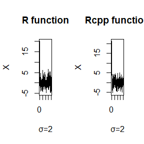

```r
fl<-function(x) 0.5*exp(-abs(x))
rw.Metropolis <- function(sigma, x0, N) {
  x <- numeric(N)
  x[1] <- x0
  u <- runif(N)
  k <- 0
  for (i in 2:N) {
    y <- rnorm(1, x[i-1], sigma)
    if (u[i] <= (fl(y) / fl(x[i-1])))
      x[i] <- y else {
        x[i] <- x[i-1]
        k <- k + 1
      }
  }
  return(list(x=x, k=k))
}
N <- 2000
sigma <- c(.05, .5, 2, 16)
x0 <- 20
set.seed(1278)
rw3 <- rw.Metropolis(sigma[3], x0, N)
rwc3<- rw_cpp(sigma[3], x0, N)
#number of candidate points rejected
par(mfrow=c(1,2))
plot(1:length(rw3$x),rw3$x,type = 'l',xlab = 'σ=2',ylab = 'X',main='R function')
plot(1:length(rwc3$x),rwc3$x,type = 'l',xlab = 'σ=2',ylab = 'X',main='Rcpp function')
```

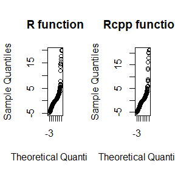

```r
qqnorm(rw3$x,main='R function',)
qqline(rw3$x)
qqnorm(rwc3$x,main='Rcpp function')
qqline(rwc3$x)
```

#### (3)

```r
library('microbenchmark')
print(c(1-rw3$k/2000, rwc3$accept.rate))
```

```
## [1] 0.5215 0.5250
```

```r
compare<- microbenchmark(rw3=rw.Metropolis(sigma[3], x0, N), rwc3=rw_cpp(sigma[3], x0, N))
compare
```

```
## Unit: microseconds
##  expr    min      lq     mean  median      uq     max neval
##   rw3 6186.1 6897.20 8662.070 7449.90 9108.55 20448.5   100
##  rwc3  356.4  362.55  431.164  378.95  432.60  2113.4   100
```

#### (4)

Acccording to the comparsion between the R function and Rcpp function, the accept rate is almost the same. And the time that Rcpp function spend is much less than the R function. It prove that Rcpp function can reduce the time.